# Final report

Rob Arbon

09/11/2020

# Introduction

The Old Faithful data set contains the waiting time between eruptions and the duration of the eruption for the Old Faithful geyser in Yellowstone National Park, Wyoming, USA.

```r
df <- faithful
```

The data description is given in the table below.

| variable | description |
| --- | --- |
| `eruptions` | the duration of the eruption, minutes |
| `waiting` | waiting time to next eruption, minutes |

A summary of the distributions of each variable are as follows:

```r
summary(df)
```

```
##    eruptions        waiting
##  Min.   :1.600   Min.   :43.0
##  1st Qu.:2.163   1st Qu.:58.0
##  Median :4.000   Median :76.0
##  Mean   :3.488   Mean   :70.9
##  3rd Qu.:4.454   3rd Qu.:82.0
##  Max.   :5.100   Max.   :96.0
```

The marginal distributions of the variables shown below:

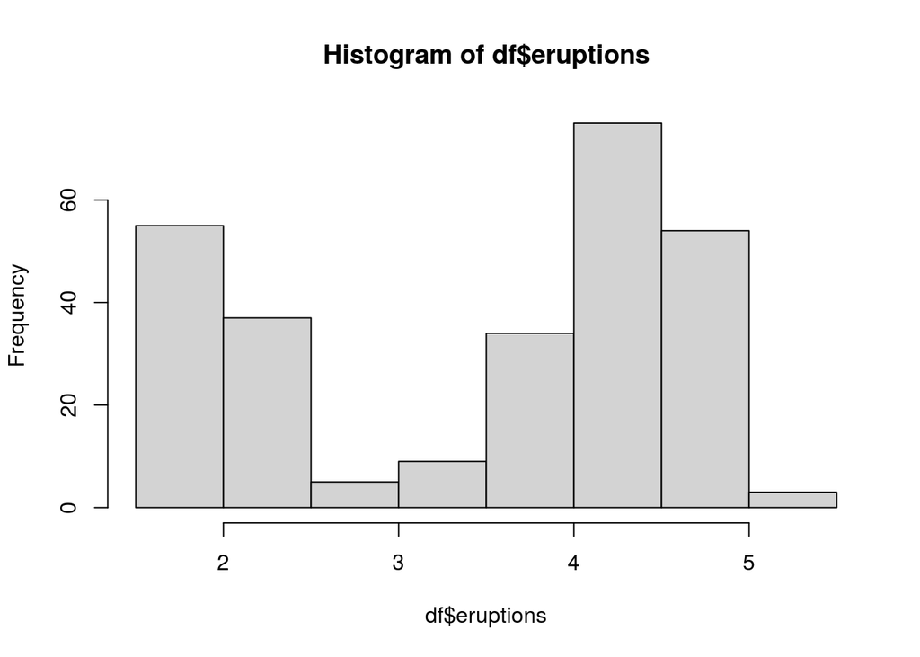

```r
hist(df$eruptions)
```

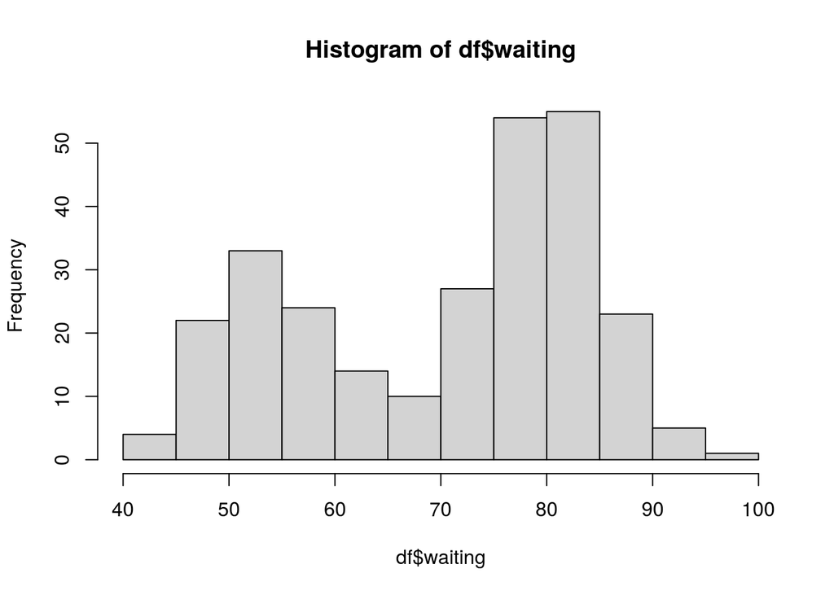

```r
hist(df$waiting)
```

Both the duration of eruptions and waiting time show a bimodal distribution. This prompts the hypothesis:

*There are 2 distinct types of eruption from Old Faithful: 1) short frequent eruptions, 2) long infrequent eruptions.*

# Methods

We will test this using a Gaussian mixture model to cluster the data into 1 and 2 clusters. The true number of clusters will correspond to the model with the smallest value of the integrated complete data likelihood (ICL).

# Results

The R package `Rmixmod` was used to estimate two Gaussian mixture models.

```r
library(Rmixmod)
# mixmodCluster fits a Gaussian mixture model
# nbCluster is the number of cluster centers
mod1 <- mixmodCluster(faithful, nbCluster=1, criterion="ICL")
mod2 <- mixmodCluster(faithful, nbCluster=2, criterion="ICL")
```

A summary of both models is shown below.

```r
summary(mod1)
```

```
## * Number of samples    =  272
## * Problem dimension    =  2
## *       Number of cluster =  1
## *              Model Type =  Gaussian_pk_Lk_C
## *               Criterion =  ICL(2607.6225)
## *              Parameters =  list by cluster
## *                  Cluster  1 :
##                          Proportion =  1.0000
##                               Means =  3.4878 70.8971
##                           Variances = |     1.2979    13.9264 |
##                                       |    13.9264   184.1438 |
## *          Log-likelihood =  -1289.7967
```

```r
summary(mod2)
```

```
## * Number of samples    =  272
## * Problem dimension    =  2
## *       Number of cluster =  2
## *              Model Type =  Gaussian_pk_Lk_C
## *               Criterion =  ICL(2324.3015)
## *              Parameters =  list by cluster
## *                  Cluster  1 :
##                          Proportion =  0.6429
##                               Means =  4.2922 79.9964
##                           Variances = |     0.1453     0.8301 |
##                                       |     0.8301    40.9021 |
## *                  Cluster  2 :
##                          Proportion =  0.3571
##                               Means =  2.0397 54.5171
##                           Variances = |     0.0984     0.5618 |
##                                       |     0.5618    27.6831 |
## *          Log-likelihood =  -1136.2599
```

The model with 2 component has the smallest value of the ICL, with a value of 2324.301484 compared to 2607.6225004 for the model with 1 component. A plot of the optimal clustering is shown below.

```
## [1] 1
```

```
## [1] 2
```

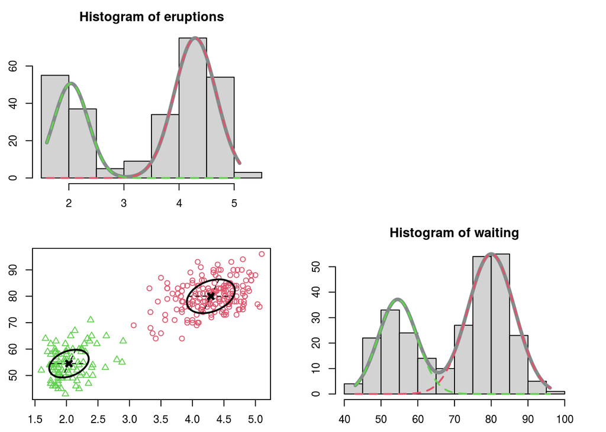

```r
plot(mod2)
```

# Conclusion

We conclude that the Old Faithful geyser has two types of eruption. A limitation of our study is that the same data was used for both exploration and hypothesis testing.